## Intro

###### Hello! I have recently completed the Google Data Analytics certificate program through Coursera. In the last course, students are asked to complete a Capstone project to showcase the skills learned. For this case study, I used R studio for the data preparation, analysis, and visualization.

## Background

###### I am a junior data analyst on the marketing team, working for Cyclistic, a successful bike-sharing fictional business launched in Chicago in 2016.

###### Our finance analysts have concluded that annual members are more profitable than casual riders.

###### Lily Moreno, our director of marketing and manager, believes there’s a chance to convert casual riders to members.

## Ask:

###### In order to achieve this goal, the marketing analyst team needs to better understand how annual members and casual riders differ..

###### There are three questions that will guide the future marketing program:

- How do annual members and casual riders use Cyclistic bikes differently?
- Why would casual riders buy Cyclistic annual membership?
- How can Cyclistic use digital media to influence casual riders to become members?

###### I have been assigned the first question to answer.

## Prepare

###### I chose to use R because it enables me to prepare, analyze, and visualize the data, all on the same platform.

#Setting up my environment

```r
install.packages("tidyverse") #for data import and wrangling
install.packages("lubridate") #for date functions
install.packages("readxl") #for reading Excel
install.packages("dplyr") # for data manipulation
library(tidyverse)
library(lubridate)
library(readxl)
library(dplyr)
```

#get working directory

```r
getwd()
```

```
## [1] "/cloud/project/Cyclistic Bike-Study"
```

#upload data sets (.xls)

```r
Divvy_Trips_2019_Q1 <- read_excel("Cyclistic Trip Data 2019/Divvy_Trips_2019_Q1.xls")
```

```r
Divvy_Trips_2019_Q2 <- read_excel("Cyclistic Trip Data 2019/Divvy_Trips_2019_Q2.xls")
```

```r
Divvy_Trips_2019_Q3 <- read_excel("Cyclistic Trip Data 2019/Divvy_Trips_2019_Q3.xls")
```

```r
Divvy_Trips_2019_Q4 <- read_excel("Cyclistic Trip Data 2019/Divvy_Trips_2019_Q4.xls")
```

#compare column names

```r
colnames(Divvy_Trips_2019_Q1)
```

```
##  [1] "trip_id"           "start_time"        "end_time"
##  [4] "bike_id"           "from_station_id"   "from_station_name"
##  [7] "to_station_id"     "to_station_name"   "usertype"
## [10] "gender"            "birthyear"         "ride_length"
## [13] "day_of_week"
```

```r
colnames(Divvy_Trips_2019_Q2)
```

```
##  [1] "trip_id"           "start_time"        "end_time"
##  [4] "bike_id"           "from_station_id"   "from_station_name"
##  [7] "to_station_id"     "to_station_name"   "usertype"
## [10] "gender"            "birthyear"         "ride_length"
## [13] "day_of_week"
```

```r
colnames(Divvy_Trips_2019_Q3)
```

```
##  [1] "trip_id"           "start_time"        "end_time"
##  [4] "bike_id"           "from_station_id"   "from_station_name"
##  [7] "to_station_id"     "to_station_name"   "usertype"
## [10] "gender"            "birthyear"         "ride_length"
## [13] "day_of_week"
```

```r
colnames(Divvy_Trips_2019_Q4)
```

```
##  [1] "trip_id"           "start_time"        "end_time"
##  [4] "bikei_d"           "from_station_id"   "from_station_name"
##  [7] "to_station_id"     "to_station_name"   "usertype"
## [10] "gender"            "birthyear"         "ride_length"
## [13] "day_of_week"
```

#insect data frames and look for incongruencies

```r
str(Divvy_Trips_2019_Q1)
```

```
## tibble [65,535 × 13] (S3: tbl_df/tbl/data.frame)
##  $ trip_id          : num [1:65535] 21742443 21742444 21742445 21742446 21742447 ...
##  $ start_time       : POSIXct[1:65535], format: "2019-01-01 00:04:37" "2019-01-01 00:08:13" ...
##  $ end_time         : POSIXct[1:65535], format: "2019-01-01 00:11:07" "2019-01-01 00:15:34" ...
##  $ bike_id          : num [1:65535] 2167 4386 1524 252 1170 ...
##  $ from_station_id  : num [1:65535] 199 44 15 123 173 98 98 211 150 268 ...
##  $ from_station_name: chr [1:65535] "Wabash Ave & Grand Ave" "State St & Randolph St" "Racine Ave & 18th St" "California Ave & Milwaukee Ave" ...
##  $ to_station_id    : num [1:65535] 84 624 644 176 35 49 49 142 148 141 ...
##  $ to_station_name  : chr [1:65535] "Milwaukee Ave & Grand Ave" "Dearborn St & Van Buren St (*)" "Western Ave & Fillmore St (*)" "Clark St & Elm St" ...
##  $ usertype         : chr [1:65535] "Subscriber" "Subscriber" "Subscriber" "Subscriber" ...
##  $ gender           : chr [1:65535] "Male" "Female" "Female" "Male" ...
##  $ birthyear        : num [1:65535] 1989 1990 1994 1993 1994 ...
##  $ ride_length      : POSIXct[1:65535], format: "1899-12-31 00:06:30" "1899-12-31 00:07:21" ...
##  $ day_of_week      : num [1:65535] 3 3 3 3 3 3 3 3 3 3 ...
```

```r
str(Divvy_Trips_2019_Q2)
```

```
## tibble [65,535 × 13] (S3: tbl_df/tbl/data.frame)
##  $ trip_id          : num [1:65535] 22178529 22178530 22178531 22178532 22178533 ...
##  $ start_time       : POSIXct[1:65535], format: "2019-04-01 00:02:22" "2019-04-01 00:03:02" ...
##  $ end_time         : POSIXct[1:65535], format: "2019-04-01 00:09:48" "2019-04-01 00:20:30" ...
##  $ bike_id          : num [1:65535] 6251 6226 5649 4151 3270 ...
##  $ from_station_id  : num [1:65535] 81 317 283 26 202 420 503 260 211 211 ...
##  $ from_station_name: chr [1:65535] "Daley Center Plaza" "Wood St & Taylor St" "LaSalle St & Jackson Blvd" "McClurg Ct & Illinois St" ...
##  $ to_station_id    : num [1:65535] 56 59 174 133 129 426 500 499 211 211 ...
##  $ to_station_name  : chr [1:65535] "Desplaines St & Kinzie St" "Wabash Ave & Roosevelt Rd" "Canal St & Madison St" "Kingsbury St & Kinzie St" ...
##  $ usertype         : chr [1:65535] "Subscriber" "Subscriber" "Subscriber" "Subscriber" ...
##  $ gender           : chr [1:65535] "Male" "Female" "Male" "Male" ...
##  $ birthyear        : num [1:65535] 1975 1984 1990 1993 1992 ...
##  $ ride_length      : POSIXct[1:65535], format: "1899-12-31 00:07:26" "1899-12-31 00:17:28" ...
##  $ day_of_week      : num [1:65535] 2 2 2 2 2 2 2 2 2 2 ...
```

```r
str(Divvy_Trips_2019_Q3)
```

```
## tibble [65,535 × 13] (S3: tbl_df/tbl/data.frame)
##  $ trip_id          : num [1:65535] 23479388 23479389 23479390 23479391 23479392 ...
##  $ start_time       : POSIXct[1:65535], format: "2019-07-01 00:00:27" "2019-07-01 00:01:16" ...
##  $ end_time         : POSIXct[1:65535], format: "2019-07-01 00:20:41" "2019-07-01 00:18:44" ...
##  $ bike_id          : num [1:65535] 3591 5353 6180 5540 6014 ...
##  $ from_station_id  : num [1:65535] 117 381 313 313 168 300 168 313 43 43 ...
##  $ from_station_name: chr [1:65535] "Wilton Ave & Belmont Ave" "Western Ave & Monroe St" "Lakeview Ave & Fullerton Pkwy" "Lakeview Ave & Fullerton Pkwy" ...
##  $ to_station_id    : num [1:65535] 497 203 144 144 62 232 62 144 195 195 ...
##  $ to_station_name  : chr [1:65535] "Kimball Ave & Belmont Ave" "Western Ave & 21st St" "Larrabee St & Webster Ave" "Larrabee St & Webster Ave" ...
##  $ usertype         : chr [1:65535] "Subscriber" "Customer" "Customer" "Customer" ...
##  $ gender           : chr [1:65535] "Male" NA NA NA ...
##  $ birthyear        : num [1:65535] 1992 NA NA NA NA ...
##  $ ride_length      : POSIXct[1:65535], format: "1899-12-31 00:20:14" "1899-12-31 00:17:28" ...
##  $ day_of_week      : num [1:65535] 2 2 2 2 2 2 2 2 2 2 ...
```

```r
str(Divvy_Trips_2019_Q4)
```

```
## tibble [65,535 × 13] (S3: tbl_df/tbl/data.frame)
##  $ trip_id          : num [1:65535] 25223640 25223641 25223642 25223643 25223644 ...
##  $ start_time       : POSIXct[1:65535], format: "2019-10-01 00:01:39" "2019-10-01 00:02:16" ...
##  $ end_time         : POSIXct[1:65535], format: "2019-10-01 00:17:20" "2019-10-01 00:06:34" ...
##  $ bikei_d          : num [1:65535] 2215 6328 3003 3275 5294 ...
##  $ from_station_id  : num [1:65535] 20 19 84 313 210 156 84 156 156 336 ...
##  $ from_station_name: chr [1:65535] "Sheffield Ave & Kingsbury St" "Throop (Loomis) St & Taylor St" "Milwaukee Ave & Grand Ave" "Lakeview Ave & Fullerton Pkwy" ...
##  $ to_station_id    : num [1:65535] 309 241 199 290 382 226 142 463 463 336 ...
##  $ to_station_name  : chr [1:65535] "Leavitt St & Armitage Ave" "Morgan St & Polk St" "Wabash Ave & Grand Ave" "Kedzie Ave & Palmer Ct" ...
##  $ usertype         : chr [1:65535] "Subscriber" "Subscriber" "Subscriber" "Subscriber" ...
##  $ gender           : chr [1:65535] "Male" "Male" "Female" "Male" ...
##  $ birthyear        : num [1:65535] 1987 1998 1991 1990 1987 ...
##  $ ride_length      : POSIXct[1:65535], format: "1899-12-31 00:15:41" "1899-12-31 00:04:18" ...
##  $ day_of_week      : num [1:65535] 3 3 3 3 3 3 3 3 3 3 ...
```

#stack quarter frames into one frame

```r
all_trips <- bind_rows(Divvy_Trips_2019_Q1, Divvy_Trips_2019_Q2, Divvy_Trips_2019_Q3, Divvy_Trips_2019_Q4)
```

## Process

#inspect new table

```r
colnames(all_trips) #list of column names
```

```
##  [1] "trip_id"           "start_time"        "end_time"
##  [4] "bike_id"           "from_station_id"   "from_station_name"
##  [7] "to_station_id"     "to_station_name"   "usertype"
## [10] "gender"            "birthyear"         "ride_length"
## [13] "day_of_week"       "bikei_d"
```

```r
dim(all_trips) #dimensions of data frame
```

```
## [1] 262140     14
```

```r
head(all_trips) #see the first 6 rows of data frame; also tail(all_trips)
```

```
## # A tibble: 6 × 14
##    trip_id start_time          end_time            bike_id from_statio…¹ from_…²
##      <dbl> <dttm>              <dttm>                <dbl>         <dbl> <chr>
## 1 21742443 2019-01-01 00:04:37 2019-01-01 00:11:07    2167           199 Wabash…
## 2 21742444 2019-01-01 00:08:13 2019-01-01 00:15:34    4386            44 State …
## 3 21742445 2019-01-01 00:13:23 2019-01-01 00:27:12    1524            15 Racine…
## 4 21742446 2019-01-01 00:13:45 2019-01-01 00:43:28     252           123 Califo…
## 5 21742447 2019-01-01 00:14:52 2019-01-01 00:20:56    1170           173 Mies v…
## 6 21742448 2019-01-01 00:15:33 2019-01-01 00:19:09    2437            98 LaSall…
## # … with 8 more variables: to_station_id <dbl>, to_station_name <chr>,
## #   usertype <chr>, gender <chr>, birthyear <dbl>, ride_length <dttm>,
## #   day_of_week <dbl>, bikei_d <dbl>, and abbreviated variable names
## #   ¹from_station_id, ²from_station_name
```

```r
str(all_trips) #see list of columns and data types
```

```
## tibble [262,140 × 14] (S3: tbl_df/tbl/data.frame)
##  $ trip_id          : num [1:262140] 21742443 21742444 21742445 21742446 21742447 ...
##  $ start_time       : POSIXct[1:262140], format: "2019-01-01 00:04:37" "2019-01-01 00:08:13" ...
##  $ end_time         : POSIXct[1:262140], format: "2019-01-01 00:11:07" "2019-01-01 00:15:34" ...
##  $ bike_id          : num [1:262140] 2167 4386 1524 252 1170 ...
##  $ from_station_id  : num [1:262140] 199 44 15 123 173 98 98 211 150 268 ...
##  $ from_station_name: chr [1:262140] "Wabash Ave & Grand Ave" "State St & Randolph St" "Racine Ave & 18th St" "California Ave & Milwaukee Ave" ...
##  $ to_station_id    : num [1:262140] 84 624 644 176 35 49 49 142 148 141 ...
##  $ to_station_name  : chr [1:262140] "Milwaukee Ave & Grand Ave" "Dearborn St & Van Buren St (*)" "Western Ave & Fillmore St (*)" "Clark St & Elm St" ...
##  $ usertype         : chr [1:262140] "Subscriber" "Subscriber" "Subscriber" "Subscriber" ...
##  $ gender           : chr [1:262140] "Male" "Female" "Female" "Male" ...
##  $ birthyear        : num [1:262140] 1989 1990 1994 1993 1994 ...
##  $ ride_length      : POSIXct[1:262140], format: "1899-12-31 00:06:30" "1899-12-31 00:07:21" ...
##  $ day_of_week      : num [1:262140] 3 3 3 3 3 3 3 3 3 3 ...
##  $ bikei_d          : num [1:262140] NA NA NA NA NA NA NA NA NA NA ...
```

```r
summary(all_trips)#statistical summary of data
```

```
##     trip_id           start_time
##  Min.   :21742443   Min.   :2019-01-01 00:04:37.00
##  1st Qu.:22088397   1st Qu.:2019-03-13 02:22:48.50
##  Median :22867373   Median :2019-05-20 08:54:12.00
##  Mean   :23193244   Mean   :2019-05-20 21:12:38.24
##  3rd Qu.:23972769   3rd Qu.:2019-07-26 19:45:24.00
##  Max.   :25292283   Max.   :2019-10-05 14:46:09.00
##
##     end_time                         bike_id      from_station_id
##  Min.   :2019-01-01 00:11:07.00   Min.   :   1    Min.   :  2.0
##  1st Qu.:2019-03-14 20:20:31.75   1st Qu.:1724    1st Qu.: 77.0
##  Median :2019-06-14 05:42:59.50   Median :3426    Median :174.0
##  Mean   :2019-05-20 21:32:32.79   Mean   :3383    Mean   :200.8
##  3rd Qu.:2019-07-28 18:39:10.00   3rd Qu.:5076    3rd Qu.:289.0
##  Max.   :2019-12-14 18:05:37.00   Max.   :6471    Max.   :673.0
##                                   NA's   :65535
##  from_station_name  to_station_id   to_station_name      usertype
##  Length:262140      Min.   :  2.0   Length:262140      Length:262140
##  Class :character   1st Qu.: 77.0   Class :character   Class :character
##  Mode  :character   Median :174.0   Mode  :character   Mode  :character
##                     Mean   :201.1
##                     3rd Qu.:289.0
##                     Max.   :673.0
##
##     gender            birthyear      ride_length
##  Length:262140      Min.   :1899    Min.   :1899-12-31 00:01:01.00
##  Class :character   1st Qu.:1978    1st Qu.:1899-12-31 00:06:21.00
##  Mode  :character   Median :1987    Median :1899-12-31 00:10:40.00
##                     Mean   :1983    Mean   :1899-12-31 00:19:54.23
##                     3rd Qu.:1991    3rd Qu.:1899-12-31 00:18:56.00
##                     Max.   :2003    Max.   :1900-03-11 07:36:14.00
##                     NA's   :30282
##   day_of_week       bikei_d
##  Min.   :1.000   Min.   :   2
##  1st Qu.:3.000   1st Qu.:1688
##  Median :4.000   Median :3409
##  Mean   :4.026   Mean   :3349
##  3rd Qu.:5.000   3rd Qu.:4996
##  Max.   :7.000   Max.   :6471
##                  NA's   :196605
```

#see how many observations fall under each usertype

```r
table(all_trips$usertype)
```

```
##
##   Customer Subscriber
##      44833     217307
```

#in the “usertype” column, replace “Subscriber” with “member” and “Customer” with “casual”

```r
all_trips <- all_trips %>%
  mutate(usertype = recode(usertype, "Subscriber" = "Member", "Customer" = "Casual"))
```

#check to make sure observations were properly changed

```r
table(all_trips$usertype)
```

```
##
## Casual Member
##  44833 217307
```

#add columns that list the date, month, day, and year of each ride #this will allow us to aggregate ride data for each month, day, or year

```r
all_trips$date<-as.Date(all_trips$start_time)
all_trips$month<-format(as.Date(all_trips$date),"%m")
all_trips$day <- format(as.Date(all_trips$date), "%Y")
all_trips$day <- format(as.Date(all_trips$date),'%d' )
all_trips$year <- format(as.Date(all_trips$date), "%Y")
all_trips$day_of_week <-format(as.Date(all_trips$date),"%A")
```

#inspect structure of columns

```r
str(all_trips)
```

```
## tibble [262,140 × 18] (S3: tbl_df/tbl/data.frame)
##  $ trip_id          : num [1:262140] 21742443 21742444 21742445 21742446 21742447 ...
##  $ start_time       : POSIXct[1:262140], format: "2019-01-01 00:04:37" "2019-01-01 00:08:13" ...
##  $ end_time         : POSIXct[1:262140], format: "2019-01-01 00:11:07" "2019-01-01 00:15:34" ...
##  $ bike_id          : num [1:262140] 2167 4386 1524 252 1170 ...
##  $ from_station_id  : num [1:262140] 199 44 15 123 173 98 98 211 150 268 ...
##  $ from_station_name: chr [1:262140] "Wabash Ave & Grand Ave" "State St & Randolph St" "Racine Ave & 18th St" "California Ave & Milwaukee Ave" ...
##  $ to_station_id    : num [1:262140] 84 624 644 176 35 49 49 142 148 141 ...
##  $ to_station_name  : chr [1:262140] "Milwaukee Ave & Grand Ave" "Dearborn St & Van Buren St (*)" "Western Ave & Fillmore St (*)" "Clark St & Elm St" ...
##  $ usertype         : chr [1:262140] "Member" "Member" "Member" "Member" ...
##  $ gender           : chr [1:262140] "Male" "Female" "Female" "Male" ...
##  $ birthyear        : num [1:262140] 1989 1990 1994 1993 1994 ...
##  $ ride_length      : POSIXct[1:262140], format: "1899-12-31 00:06:30" "1899-12-31 00:07:21" ...
##  $ day_of_week      : chr [1:262140] "Tuesday" "Tuesday" "Tuesday" "Tuesday" ...
##  $ bikei_d          : num [1:262140] NA NA NA NA NA NA NA NA NA NA ...
##  $ date             : Date[1:262140], format: "2019-01-01" "2019-01-01" ...
##  $ month            : chr [1:262140] "01" "01" "01" "01" ...
##  $ day              : chr [1:262140] "01" "01" "01" "01" ...
##  $ year             : chr [1:262140] "2019" "2019" "2019" "2019" ...
```

#convert “ride_length” from Factor to numeric so we can run calculations on the data

```r
is.factor(all_trips$ride_length)
```

```
## [1] FALSE
```

```r
all_trips$ride_length <- as.numeric(as.character(all_trips$ride_length))
is.numeric(all_trips$ride_length)
```

```
## [1] TRUE
```

#add a “ride_length” calculation to all_trips (in minutes & seconds)

```r
all_trips$ride_length <- difftime(all_trips$end_time, all_trips$start_time)
```

```r
all_trips_v2 <- all_trips[!(all_trips$from_station_name == "HQ QR" | all_trips$ride_length<0),]
```

## Analyze

#descriptive analysis on ride_length(all figures in minutes & seconds)

```r
mean(all_trips_v2$ride_length)
```

```
## Time difference of 19.90932 mins
```

```r
median(all_trips_v2$ride_length)
```

```
## Time difference of 10.66667 mins
```

```r
max(all_trips_v2$ride_length)
```

```
## Time difference of 102696.2 mins
```

```r
min(all_trips_v2$ride_length)
```

```
## Time difference of 1.016667 mins
```

```r
summary(all_trips_v2$ride_length)
```

```
##   Length    Class     Mode
##   262140 difftime  numeric
```

#compare members and casual users

```r
aggregate(all_trips_v2$ride_length ~ all_trips_v2$usertype, FUN = mean)
```

```
##   all_trips_v2$usertype all_trips_v2$ride_length
## 1                Casual            51.07174 mins
## 2                Member            13.48014 mins
```

```r
aggregate(all_trips_v2$ride_length ~ all_trips_v2$usertype, FUN = median)
```

```
##   all_trips_v2$usertype all_trips_v2$ride_length
## 1                Casual           25.500000 mins
## 2                Member            9.316667 mins
```

```r
aggregate(all_trips_v2$ride_length ~ all_trips_v2$ride_length, FUN = max)
```

```
##   all_trips_v2$ride_length
## 1            102696.2 mins
```

```r
aggregate(all_trips_v2$ride_length ~ all_trips_v2$ride_length, FUN = min)
```

```
##   all_trips_v2$ride_length
## 1            1.016667 mins
```

#See the average ride time by each day for members vs casual users

```r
aggregate(all_trips_v2$ride_length ~ all_trips_v2$usertype + all_trips_v2$day_of_week, FUN = mean)
```

```
##    all_trips_v2$usertype all_trips_v2$day_of_week all_trips_v2$ride_length
## 1                 Casual                   Friday            65.68698 mins
## 2                 Member                   Friday            12.10352 mins
## 3                 Casual                   Monday            43.97476 mins
## 4                 Member                   Monday            13.29304 mins
## 5                 Casual                 Saturday            53.81935 mins
## 6                 Member                 Saturday            17.37605 mins
## 7                 Casual                   Sunday            41.85205 mins
## 8                 Member                   Sunday            17.81473 mins
## 9                 Casual                 Thursday            49.49955 mins
## 10                Member                 Thursday            13.06613 mins
## 11                Casual                  Tuesday            47.98204 mins
## 12                Member                  Tuesday            12.99927 mins
## 13                Casual                Wednesday            55.31789 mins
## 14                Member                Wednesday            13.01893 mins
```

#fix the order of the days

```r
all_trips_v2$day_of_week <-ordered(all_trips_v2$day_of_week, levels=c("Sunday", "Monday", "Tuesday", "Wednesday", "Thursday", "Friday", "Saturday"))
```

#run average ride time by each day for member vs casual users

```r
aggregate(all_trips_v2$ride_length ~ all_trips_v2$usertype +
            all_trips_v2$day_of_week, FUN = mean)
```

```
##    all_trips_v2$usertype all_trips_v2$day_of_week all_trips_v2$ride_length
## 1                 Casual                   Sunday            41.85205 mins
## 2                 Member                   Sunday            17.81473 mins
## 3                 Casual                   Monday            43.97476 mins
## 4                 Member                   Monday            13.29304 mins
## 5                 Casual                  Tuesday            47.98204 mins
## 6                 Member                  Tuesday            12.99927 mins
## 7                 Casual                Wednesday            55.31789 mins
## 8                 Member                Wednesday            13.01893 mins
## 9                 Casual                 Thursday            49.49955 mins
## 10                Member                 Thursday            13.06613 mins
## 11                Casual                   Friday            65.68698 mins
## 12                Member                   Friday            12.10352 mins
## 13                Casual                 Saturday            53.81935 mins
## 14                Member                 Saturday            17.37605 mins
```

#analyze ridership data by type and weekday

```r
all_trips_v2 %>%
  mutate(weekday = wday(start_time, label = TRUE)) %>%  #creates weekday field using wday()
  group_by(usertype, day_of_week) %>%  #groups by usertype and weekday
  summarise(number_of_rides = n()       #calculates the number of rides and average duration
            ,average_duration = mean(ride_length)) %>%  # calculates the average duration
  arrange(usertype, day_of_week)    # sorts
```

```
## # A tibble: 14 × 4
## # Groups:   usertype [2]
##    usertype day_of_week number_of_rides average_duration
##    <chr>    <ord>                 <int> <drtn>
##  1 Casual   Sunday                 2784 41.85205 mins
##  2 Casual   Monday                 7175 43.97476 mins
##  3 Casual   Tuesday                6829 47.98204 mins
##  4 Casual   Wednesday              6542 55.31789 mins
##  5 Casual   Thursday               9271 49.49955 mins
##  6 Casual   Friday                 4287 65.68698 mins
##  7 Casual   Saturday               7945 53.81935 mins
##  8 Member   Sunday                 9256 17.81473 mins
##  9 Member   Monday                39506 13.29304 mins
## 10 Member   Tuesday               46045 12.99927 mins
## 11 Member   Wednesday             39965 13.01893 mins
## 12 Member   Thursday              34322 13.06613 mins
## 13 Member   Friday                31442 12.10352 mins
## 14 Member   Saturday              16771 17.37605 mins
```

#create a visualization the number of rides by rider type

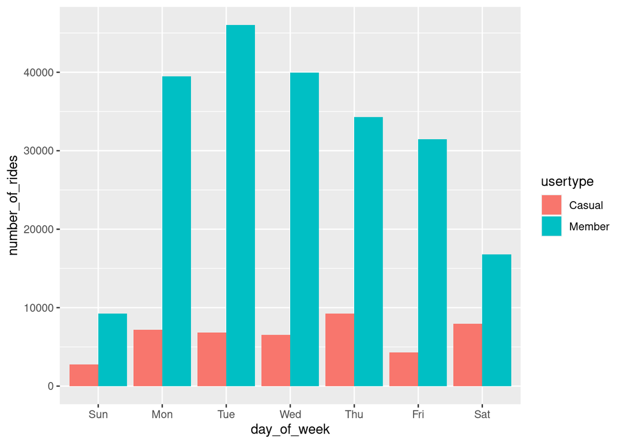

```r
all_trips_v2 %>%
    mutate(day_of_week = wday(start_time, label = TRUE)) %>%
   group_by(usertype, day_of_week) %>%
   summarise(number_of_rides = n()
              ,average_duration = mean(ride_length)) %>%
     arrange(usertype, day_of_week)  %>%
     ggplot(aes(x = day_of_week, y = number_of_rides, fill = usertype)) +
     geom_col(position = "dodge")
```

#create a visualization for average duration

```
## Defaulting to continuous.
```

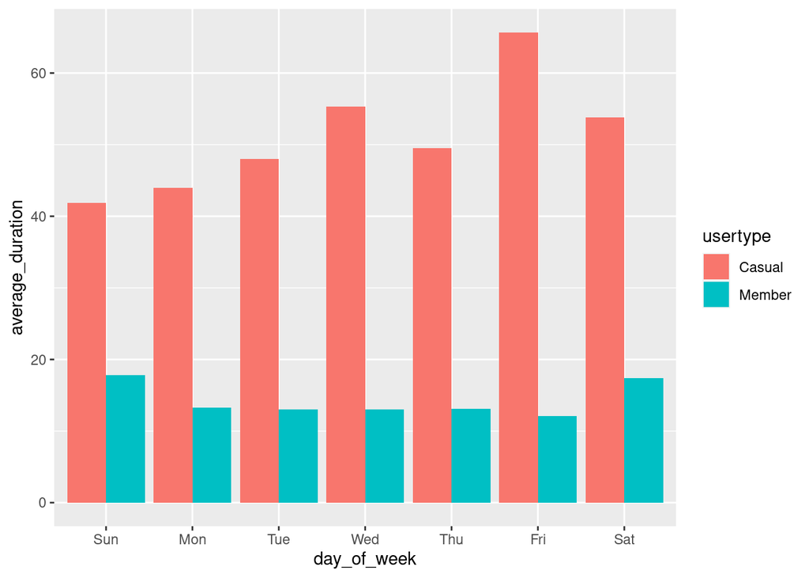

```r
all_trips_v2 %>%
  mutate(day_of_week = wday(start_time, label = TRUE)) %>%
  group_by(usertype, day_of_week) %>%
  dplyr::summarise(number_of_rides = n()
            ,average_duration = mean(ride_length)) %>%
  arrange(usertype, day_of_week)  %>%
  ggplot(aes(x = day_of_week, y = average_duration, fill = usertype)) +
  geom_col(position = "dodge")
```

## Share

#create a csv file that we will visualize in Excel, Tableau, or presentation software

```r
counts <- aggregate(all_trips_v2$ride_length ~ all_trips_v2$usertype + all_trips_v2$day_of_week, FUN = mean)
write.csv(counts, file = "10.14 >> Users >> christiejackson >> Documents >> avg_ride_length.csv")
```